# ClasseExercise

Swetha Jegannathan

01/10/2019

# PREDICT EXERCISE EFFECTIVENESS

**Objective** Predict the manner and effectiveness of exercise done by 6 participants on accelerometers on the belt, forearm, arm, and dumbell on pml-testing.csv dataset for 20 different test cases. Dependant variable is “classe” with 5 levels of classificaiton - A, B, C, D and E. The 6 users are - Adelmo Carlitos Charles Eurico Jeremy Pedro

The participants were asked to perform barbell lifts correctly and incorrectly in 5 different ways.

**Dataset** The datasets pml-training.csv and pml-testung.csv are imported into the system. The training dataset has 19622 rows and 160 variables and testing data set has 20 rows and 160 variables. There are lot of NAs, blanks and character variable in the dataset. which requires intensive cleaning.

```r
getwd()
```

```
## [1] "C:/Users/SWETHA JEGANNATHAN/Desktop/WorkingDirectory/PROJECT/cPROJECT"
```

```r
train <- read.csv("pml-training.csv", stringsAsFactors = FALSE)

test <- read.csv("pml-testing.csv", stringsAsFactors = FALSE)
set.seed(13243)

dim(train)
```

```
## [1] 19622   160
```

```r
dim(test)
```

```
## [1]  20 160
```

**Create Subset** Since the dataset has 19622 rows, for easy of calculation we take a subset of 5000 rows out of original training data

```r
train.sample <- sample(nrow(train), 5000)

train.subset <- train[train.sample,]
```

```r
train.dropna <- train.subset[,colSums(is.na(train.subset)) < 100]
train.dropchr <- train.dropna[, !sapply(train.dropna, is.character)]
train.final <- train.dropchr[,4:56]
train.final$classe <- factor(train.subset$classe) #Re-insert classe column, convert to factor
```

**Data Partition in Training data** We partition our training data into train1 - 80% and train2 - 20%. We shall build our model on train1 and predict on train2 and use this model to predict the “classe” on 20 rows in testing data.

```r
#createDataPartition: Subset 20% of training data for cross-validation
library(caret)
trainIndex <- createDataPartition(y = train.final$classe, p=0.8, list = FALSE)

train1 <- train.final[trainIndex,]

train2 <- train.final[-trainIndex,]

dim(train1)
```

```
## [1] 4002   54
```

```r
str(train1)
```

```
## 'data.frame':    4002 obs. of  54 variables:
##  $ num_window          : int  275 808 624 134 157 274 209 252 433 575 ...
##  $ roll_belt           : num  1.66 1.61 131 119 153 1.6 121 0.73 1.13 124 ...
##  $ pitch_belt          : num  3.88 3.48 21.4 16.3 6.88 1.65 -43.9 0.35 5.28 -42 ...
##  $ yaw_belt            : num  -88.4 -88.3 21.8 -2.65 49.3 -88.2 174 -88.3 -88.5 166 ...
##  $ total_accel_belt    : int  2 2 20 18 25 2 17 3 5 17 ...
##  $ gyros_belt_x        : num  0.05 0.05 -0.35 0.08 0.31 -0.1 0.11 -0.05 -0.02 0.13 ...
##  $ gyros_belt_y        : num  0 0.02 -0.03 0.11 0.02 0.02 0.11 0.02 -0.02 0.11 ...
##  $ gyros_belt_z        : num  -0.02 0.05 -0.36 -0.15 -0.43 -0.03 -0.16 0 -0.02 -0.15 ...
##  $ accel_belt_x        : int  -7 -7 -51 -22 -28 -6 50 1 -16 49 ...
##  $ accel_belt_y        : int  1 2 69 64 63 4 42 2 5 43 ...
##  $ accel_belt_z        : int  19 23 -175 -168 -238 22 -157 30 41 -155 ...
##  $ magnet_belt_x       : int  46 29 20 25 47 30 171 24 44 159 ...
##  $ magnet_belt_y       : int  565 566 583 598 451 562 611 565 625 607 ...
##  $ magnet_belt_z       : int  -439 -434 -369 -339 -542 -431 -307 -431 -313 -302 ...
```

[output cut: 40 more lines]

```r
dim(train2)
```

```
## [1] 998  54
```

```r
str(train2)
```

```
## 'data.frame':    998 obs. of  54 variables:
##  $ num_window          : int  266 329 117 222 795 167 553 283 341 520 ...
##  $ roll_belt           : num  1.53 1.32 121 0.71 1.73 133 127 -6.28 1.7 126 ...
##  $ pitch_belt          : num  2.06 7.09 25.7 4.76 -2.39 10.5 -41.5 1.3 7.94 -43.1 ...
##  $ yaw_belt            : num  -88.4 -94 -5.29 -87.9 -85.5 55.3 161 -82.9 -93.4 164 ...
##  $ total_accel_belt    : int  2 3 20 3 4 17 17 2 3 18 ...
##  $ gyros_belt_x        : num  -0.03 -0.03 -0.48 0.06 0.13 0 0.13 -0.08 0.02 0.11 ...
##  $ gyros_belt_y        : num  0 -0.02 -0.02 0 0.19 0.08 0.11 -0.29 0 0.11 ...
##  $ gyros_belt_z        : num  -0.05 -0.02 -0.46 -0.03 -0.15 -0.44 -0.16 -1.15 -0.02 -0.16 ...
##  $ accel_belt_x        : int  -6 -17 -40 -15 25 -12 49 -13 -21 52 ...
##  $ accel_belt_y        : int  3 2 73 2 7 53 43 2 5 44 ...
##  $ accel_belt_z        : int  22 22 -173 30 31 -160 -158 17 18 -159 ...
##  $ magnet_belt_x       : int  38 -6 2 56 67 17 167 72 8 159 ...
##  $ magnet_belt_y       : int  565 601 586 577 575 602 608 568 607 607 ...
##  $ magnet_belt_z       : int  -440 -310 -369 -410 -414 -327 -310 -425 -299 -312 ...
```

[output cut: 40 more lines]

```r
control <- trainControl(method="cv", number=10)
model_gbm <- train(classe~. , data = train1 , method="gbm" , trControl=control ,  verbose = FALSE )
model_gbm$finalModel
```

```
## A gradient boosted model with multinomial loss function.
## 150 iterations were performed.
## There were 53 predictors of which 53 had non-zero influence.
```

**Predict** Predict classes and probability on train2 model using the Gradient decent model build above.

```r
library(caret)
#library(ModelMetrics)
plsClasses <- predict(model_gbm, newdata = train2)
str(plsClasses)
```

```
##  Factor w/ 5 levels "A","B","C","D",..: 3 1 4 1 5 5 3 4 1 2 ...
```

```r
plsProbs <- predict(model_gbm, newdata = train2, type = "prob")
head(plsProbs)
```

```
##             A           B           C            D            E
## 1 0.002733308 0.007000618 0.986819743 0.0013369465 0.0021093846
## 2 0.993422724 0.003279318 0.001432902 0.0009245479 0.0009405074
## 3 0.009284610 0.016753364 0.042021707 0.9257889357 0.0061513832
## 4 0.977934977 0.005207053 0.010320707 0.0022989593 0.0042383028
## 5 0.007053136 0.006826518 0.008140920 0.0441244009 0.9338550254
## 6 0.006649222 0.004736997 0.001504482 0.0082307682 0.9788785302
```

**Important Variables** We identify the important variables contrubuting to understanding our predictor variable. Further, we plot the variable in the order of the importance.

```r
# Visualization
library(gbm)
library(caret)
library(splines)
library(parallel)
library(plyr)
require(RCurl)
varImp(model_gbm)
```

```
## gbm variable importance
##
##   only 20 most important variables shown (out of 53)
##
##                   Overall
## num_window        100.000
## roll_belt          70.292
## pitch_forearm      40.983
## yaw_belt           37.704
## magnet_dumbbell_z  36.707
## magnet_dumbbell_y  27.984
## pitch_belt         19.318
## magnet_belt_z      18.833
## roll_forearm       16.551
## accel_dumbbell_z   15.175
## roll_dumbbell      14.716
## gyros_belt_z       13.184
## accel_forearm_x    11.720
## accel_dumbbell_y    9.903
## magnet_forearm_z    9.687
## accel_forearm_z     6.579
## accel_dumbbell_x    6.283
## gyros_dumbbell_y    5.923
## gyros_dumbbell_x    5.346
## yaw_arm             5.341
```

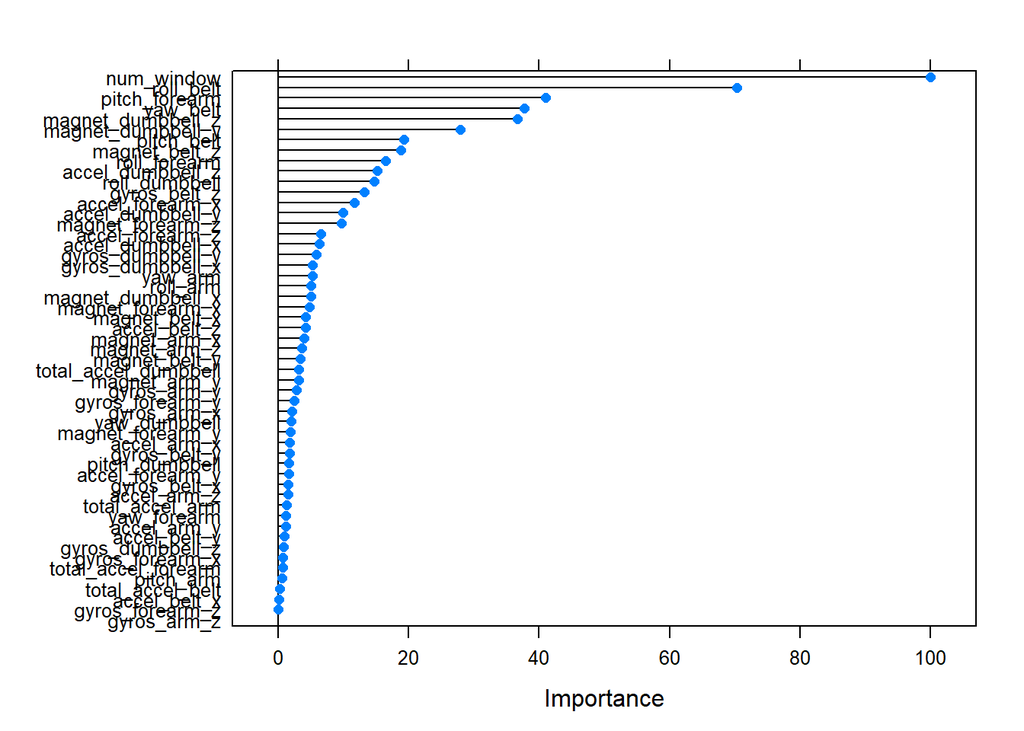

```r
plot(varImp(model_gbm))
```

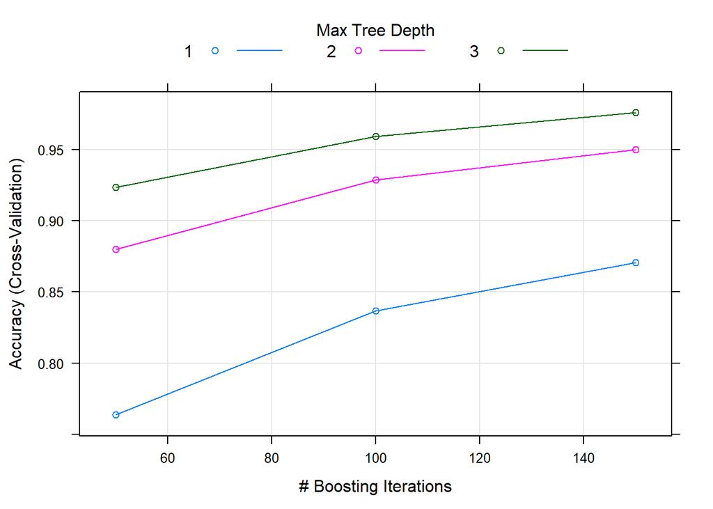

```r
plot(model_gbm)
```

```r
model_gbm
```

```
## Stochastic Gradient Boosting
##
## 4002 samples
##   53 predictor
##    5 classes: 'A', 'B', 'C', 'D', 'E'
##
## No pre-processing
## Resampling: Cross-Validated (10 fold)
## Summary of sample sizes: 3600, 3601, 3601, 3602, 3602, 3602, ...
## Resampling results across tuning parameters:
##
##   interaction.depth  n.trees  Accuracy   Kappa
##   1                   50      0.7636432  0.7001063
##   1                  100      0.8368450  0.7937422
##   1                  150      0.8705846  0.8364387
##   2                   50      0.8800666  0.8483144
##   2                  100      0.9285375  0.9096118
##   2                  150      0.9497828  0.9364961
##   3                   50      0.9232950  0.9029687
##   3                  100      0.9592816  0.9485037
##   3                  150      0.9757636  0.9693568
##
## Tuning parameter 'shrinkage' was held constant at a value of 0.1
##
## Tuning parameter 'n.minobsinnode' was held constant at a value of 10
## Accuracy was used to select the optimal model using the largest value.
## The final values used for the model were n.trees = 150,
##  interaction.depth = 3, shrinkage = 0.1 and n.minobsinnode = 10.
```

```r
cross_validation_results_boost <- predict(model_gbm , newdata = test)

predict.test.gbm <- predict(model_gbm , newdata = test )
predict.test.gbm
```

```
##  [1] B A B A A E D B A A B C B A E E A B B B
## Levels: A B C D E
```

```r
plsClasses1 <- predict(model_gbm, newdata = test)
plsClasses1
```

```
##  [1] B A B A A E D B A A B C B A E E A B B B
## Levels: A B C D E
```

```r
str(plsClasses)
```

```
##  Factor w/ 5 levels "A","B","C","D",..: 3 1 4 1 5 5 3 4 1 2 ...
```

```r
plsProbs1 <- predict(model_gbm, newdata = test, type = "prob")
head(plsProbs1)
```

```
##             A           B           C           D           E
## 1 0.038630091 0.634467400 0.194670468 0.101515263 0.030716778
## 2 0.961296535 0.026867265 0.007294512 0.002215277 0.002326411
## 3 0.081180273 0.813224864 0.059323320 0.024071092 0.022200452
## 4 0.981793082 0.001536142 0.011474870 0.004177138 0.001018767
## 5 0.929769738 0.037428401 0.017211141 0.005618721 0.009971998
## 6 0.001100094 0.013064783 0.040716967 0.003793686 0.941324469
```

**Prediction of “Classe” on 20 rows**

```r
plsClasses1 <- predict(model_gbm, newdata = test)

data.frame("Predictions" = plsClasses1)
```

```
##    Predictions
## 1            B
## 2            A
## 3            B
## 4            A
## 5            A
## 6            E
## 7            D
## 8            B
## 9            A
## 10           A
## 11           B
## 12           C
## 13           B
## 14           A
## 15           E
## 16           E
## 17           A
## 18           B
## 19           B
## 20           B
```